# 5. 파이썬 자료형 알아보기

- 파이썬은 기본 자료형을 다양한 클래스로 제공한다.

```python
from IPython.display import Image
```

### 내장 자료형을 알아보기

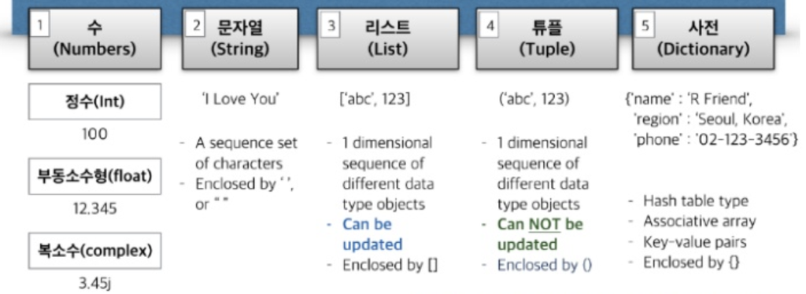

```python
Image("./이미지/5가지자료구조.png", width=700, height=700)
```

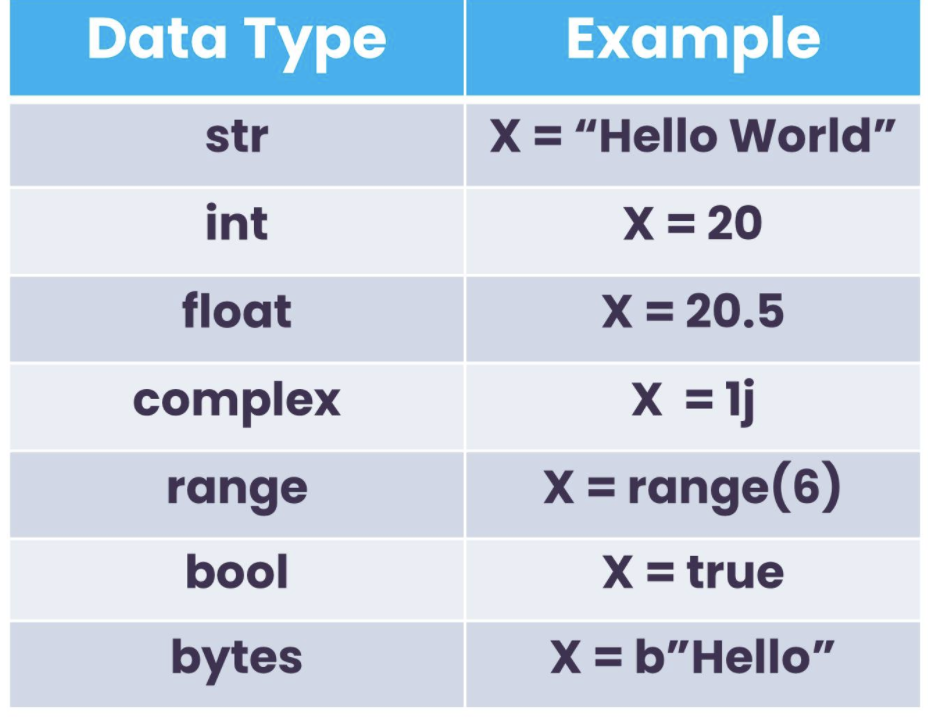

```python
Image("./이미지/데이터타입.png", width=500, height=500)
```

# 5-1 숫자 자료형

- 정수, 실수, 복소수를 지원함
- 숫자 자료형은 숫자 클래스인 int, float, complex의 객체

### 정수

- 0과 양의 부호, 음의 부호를 가지는 숫자 집합

```python
int
```

```
int
```

### 정수의 객체 만들기

- 리터럴 표기법인 숫자를 직접 표시한다
- int 클래스로 객체를 생성한다

```python
100
```

```
100
```

```python
int(100)
```

```
100
```

### 정수 객체 여부를 확인하기

- 정수 클래스와의 관계를 isinstance 함수로 확인
- **class** 속성으로 확인
- type 클래스로 확인

```python
isinstance(100, int)
```

```
True
```

```python
(100).__class__
```

```
int
```

```python
type(100)
```

```
int
```

# 5-2 문자열

- 유니코드 문자열 str과 바이트 문자열 bytes 클래스를 지원
- 기본 문자열은 변경할 수 없다.
- 문자열의 모든 원소는 문자로 구성한다.
- 유니코드 문자열과 바이트 문자열은 변환이 가능하다.

### 문자열은 따옴표를 사용해서 내부에 문자를 입력해서 만든다

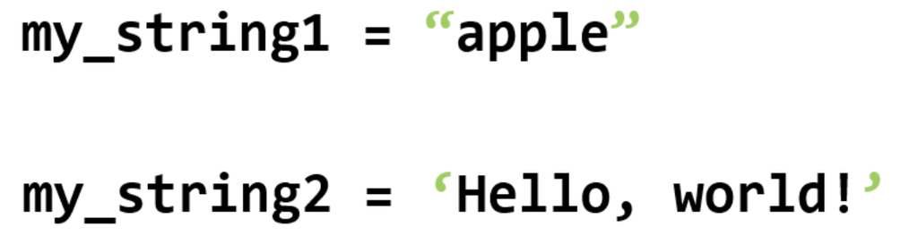

```python
Image("./이미지/문자열.png", width=500, height=500)
```

### 빈 문자열은 문자가 없는 따옴표를 사용한다.

```python
s =""
```

### 문자열을 만든다. 파이썬은 기본 유니코드 문자열은 str 이다

```python
ss = "문자열"
```

```python
type(ss)
```

```
str
```

### 유니코드 문자열을 바이트 문자열로 변환한다

```python
bb = ss.encode()
```

```python
type(bb)
```

```
bytes
```

### 바이트 문자열은 한 바이트씩 표시한다

```python
bb
```

```
b'\xeb\xac\xb8\xec\x9e\x90\xec\x97\xb4'
```

### 바이트 문자열은 유니코드 문자열로 변환한다

```python
ss_1 = bb.decode()
```

```python
type(ss_1)
```

```
str
```

```python
ss_1
```

```
'문자열'
```

# 5-3 리스트

- 여러 원소로 구성이 가능한 컨테이너 클래스이다.
- 파이썬 object 클래스를 상속한 모든 객체가 원소가 될 수 있다.

### 리스트는 대괄호 사이에 원소들을 넣고 쉼표로 구분

```python
l = [1,2,3,4]
```

```python
type(l)
```

```
list
```

### 리스트 생성자로 리스트 객체 만들기

```python
s = list('리스트')
```

```python
s
```

```
['리', '스', '트']
```

### 리스트 와 함수 및 객체 내의 메소드

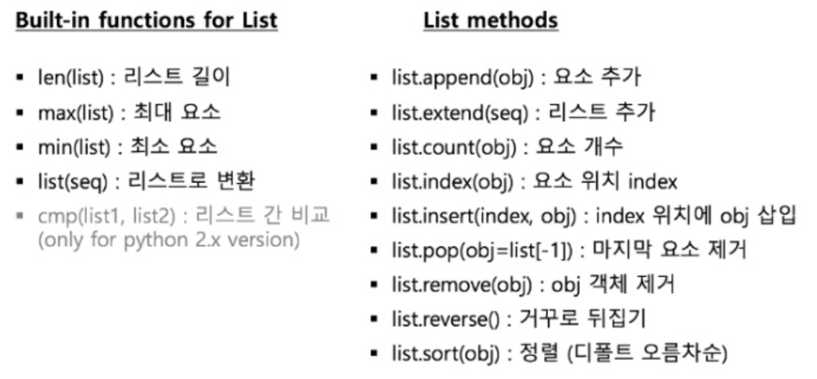

```python
Image("./이미지/리스트메소드.png", width=500, height=500)
```

### 빈 리스트를 만들고 객체를 추가하기

```python
blank_list =[]
```

```python
blank_list
```

```
[]
```

### 하나의 원소를 추가하기

```python
blank_list.append(1)
```

```python
blank_list
```

```
[1]
```

### 하나의 원소를 특정 인덱스 위치에 추가하기

```python
blank_list.insert(0,2)
```

```python
blank_list
```

```
[2, 1]
```

### 여러개 원소를 합치기

```python
blank_list.extend([1,2,3,4])
```

```python
blank_list
```

```
[2, 1, 1, 2, 3, 4]
```

### 리스트 컴프리헨션 사용하기

- 리스트객체를 만들 때 원소를 나열하지 않고 수식으로 표현하기
- 하나의 라인에 for 와 if를 작성

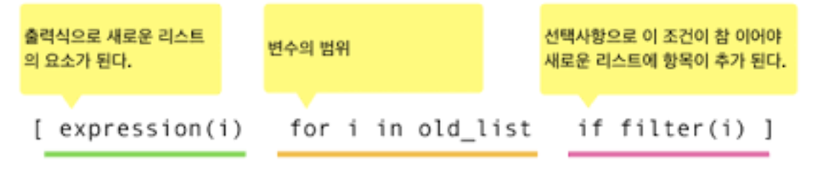

```python
Image("./이미지/리스트컴프리헨션.png", width=500, height=500)
```

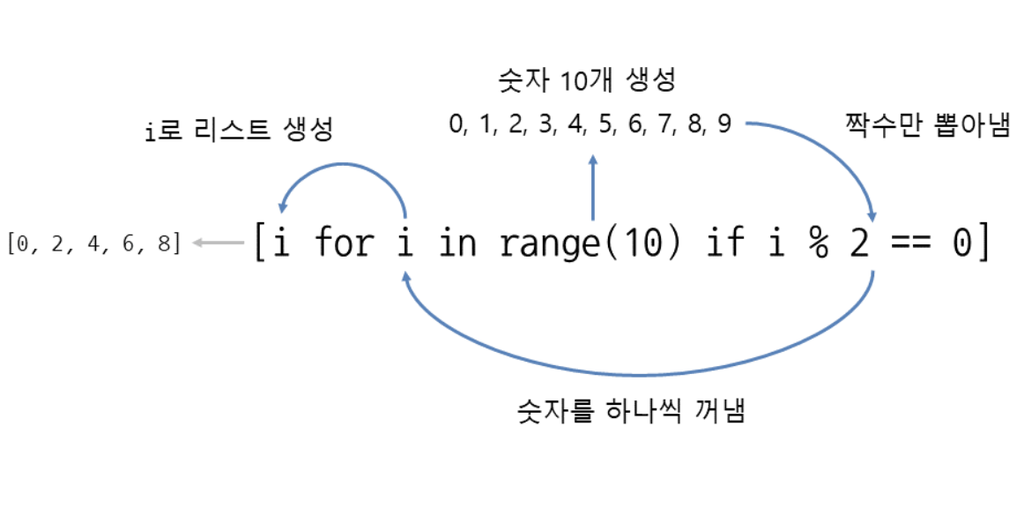

```python
Image("./이미지/리스트컴프리헨션1.png", width=500, height=500)
```

### for 만 사용하면 전체 원소를 가진 리스트를 만든다

```python
[i for i in range(10)]
```

```
[0, 1, 2, 3, 4, 5, 6, 7, 8, 9]
```

### if 를 사용해서 제약을 주면 참인 경우만 원소로 만들어진다

```python
[i for i in range(10) if i % 2 == 0]
```

```
[0, 2, 4, 6, 8]
```

# 5-4 튜플

- 리스트의 변결할 수 없는 클래스이다

### 튜플은 소괄호로 지정한다.

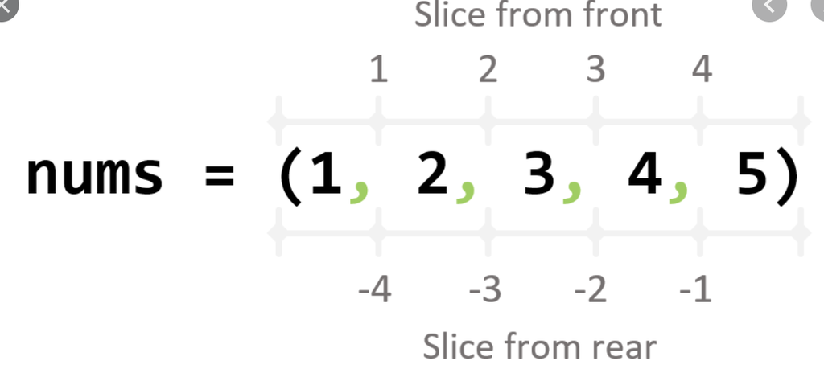

```python
Image("./이미지/튜플인덱스.png", width=500, height=500)
```

### 하나의 원소를 가진 튜플을 표시할 때는 반드시 쉼표를 넣는다

```python
a = (1,)
```

```python
a
```

```
(1,)
```

### 아무것도 없는 튜플을 만들때는 빈 소괄호로 표시한다

```python
b = ()
```

```python
b
```

```
()
```

```python
Image("./이미지/튜플메소드.gif", width=500, height=500)
```

[output not shown]

# 5-5 집합

- 모든 원소는 유일한 값만 보관하는 클래스

### 빈 집합을 만든다

```python
s = set()
```

```python
s
```

```
set()
```

### 원소를 추가한다

```python
s.add(1)
```

```python
s
```

```
{1}
```

```python
s.add(2)
```

```python
s
```

```
{1, 2}
```

### 동일한 원소를 추가하면 각 원소는 유일하므로 변경되지 않는다

```python
s.add(2)
```

```python
s
```

```
{1, 2}
```

# 5-6 딕셔너리

- 키와 값을 가지는 원소들을 가지는 컨테이터 클래스이다

### 빈 딕셔너리 만들때는 중괄호를 사용한다

```python
d = {}
```

```python
type(d)
```

```
dict
```

### 빈 딕셔너리에 하나의 키와 값을 추가한다

```python
d.update({'a': 100})
```

```python
d
```

```
{'a': 100}
```

### 딕셔너리 키는 해시를 처리해서 내부적으로 유일한 값만 가진다.

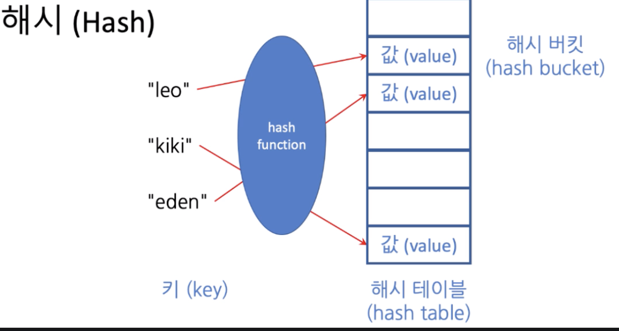

```python
Image("./이미지/딕셔너리해시.png", width=600, height=600)
```

#### 딕셔너리에 키는 유일하므로 동일한 키로 갱신하면 값만 변경된다

```python
d.update({'a': 300})
```

```python
d
```

```
{'a': 300}
```

#### 딕셔너리를 딕셔너리 컴퓨리헨션으로 표시하기

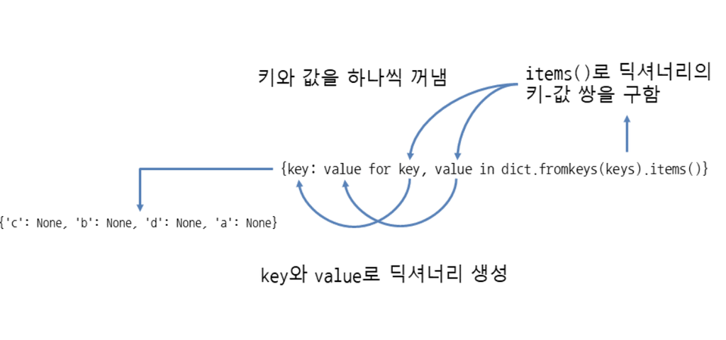

```python
Image("./이미지/딕셔너리.png", width=600, height=600)
```

### 두개의 원소를 가지는 딕셔너리를 만든다.

```python
d_1 = {1:100, 2: 200}
```

#### 딕셔너리 내부의 키, 값, 키와 값을 하나씩 조회한다

```python
d_1.keys()
```

```
dict_keys([1, 2])
```

```python
d_1.values()
```

```
dict_values([100, 200])
```

```python
d_1.items()
```

```
dict_items([(1, 100), (2, 200)])
```

### 딕셔너리를 축약형으로 표시할 때는 키와 값을 표시한다

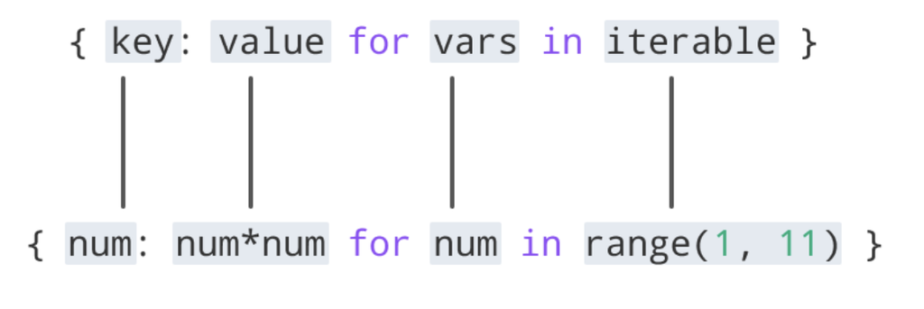

```python
Image("./이미지/딕셔너리컴프리헨션.png", width=600, height=600)
```

```python
{key:value for key, value in d_1.items()}
```

```
{1: 100, 2: 200}
```

## 5-7 인덱싱과 슬라이싱

- 여러 원소를 가지는 리스트, 튜플, 문자열은 내부의 원소를 조회할 때 위치정보인 인덱스로 조회할 수 있다.

### 인덱스 : 위치정보 알아보기

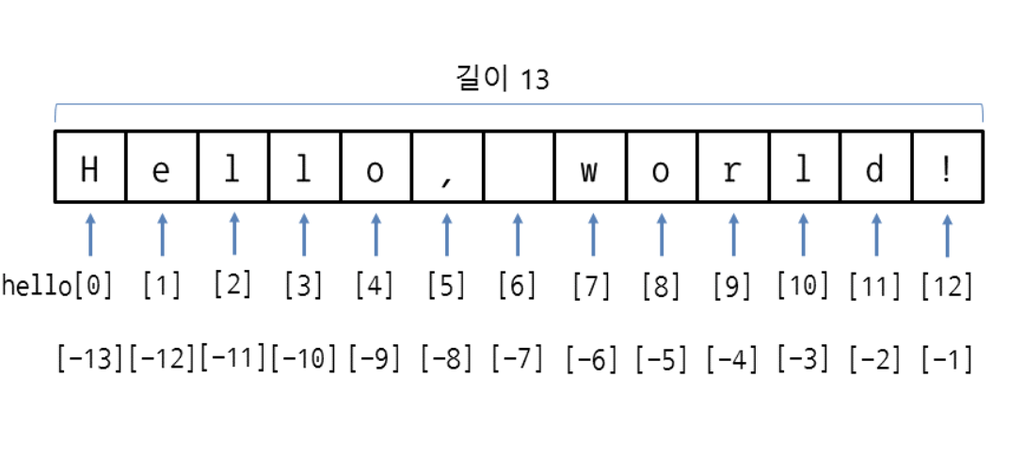

```python
Image("./이미지/인덱스.png", width=500, height=500)
```

### 인덱싱

- 내부의 원소를 검색하기

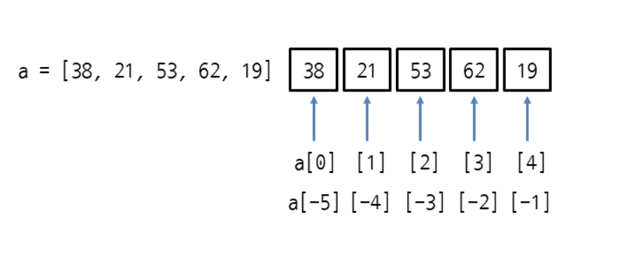

```python
Image("./이미지/인덱싱.png", width=500, height=500)
```

### 특정 부분만을 추출할 경우 슬라이스를 사용한다

- 시작위치, 종료위치, 간격을 지정해서 부분을 추출할 수 있다

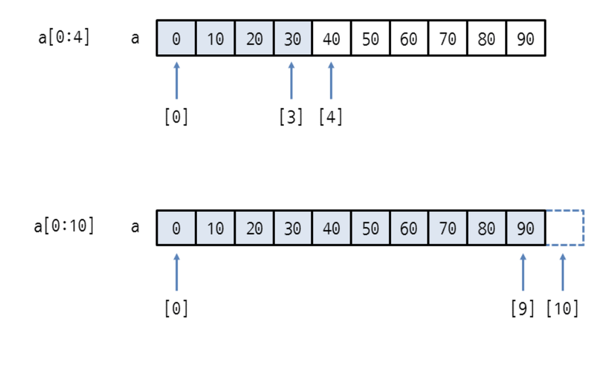

```python
Image("./이미지/슬라이스.png", width=500, height=500)
```